# Biomedical Data Visualisation

Nikita Zaitsev

2024-09-22

### Data reading

```r
hogwarts <- read_csv("data/hogwarts_2024.csv")


hogwarts <- hogwarts %>%
  mutate(across(c(house, sex, wandCore, bloodStatus, course, id), ~ as.factor(.x)))
glimpse(hogwarts)
```

```
## Rows: 560
## Columns: 60
## $ id                                   <fct> 1, 2, 3, 4, 5, 6, 7, 8, 9, 10, 11…
## $ house                                <fct> Ravenclaw, Hufflepuff, Ravenclaw,…
## $ course                               <fct> 4, 5, 4, 2, 2, 6, 7, 5, 2, 3, 7, …
## $ sex                                  <fct> female, male, female, male, femal…
## $ wandCore                             <fct> unicorn hair, phoenix feather, dr…
## $ bloodStatus                          <fct> half-blood, half-blood, half-bloo…
## $ result                               <dbl> 94, 33, 137, 27, 67, 126, 63, 7, …
## $ `Defence against the dark arts exam` <dbl> 73, 38, 52, 50, 47, 44, 51, 47, 2…
## $ `Flying exam`                        <dbl> 33, 36, 73, 42, 41, 52, 34, 34, 2…
## $ `Astronomy exam`                     <dbl> 57, 45, 66, 49, 57, 59, 58, 37, 5…
## $ `Herbology exam`                     <dbl> 73, 50, 62, 39, 38, 46, 59, 23, 2…
## $ `Divinations exam`                   <dbl> 66, 54, 72, 42, 47, 49, 42, 38, 1…
## $ `Charms exam`                        <dbl> 60, 70, 77, 46, 35, 55, 86, 20, 4…
```

[output cut: 47 more lines]

## Столбчатые диаграммы

### Задание 1

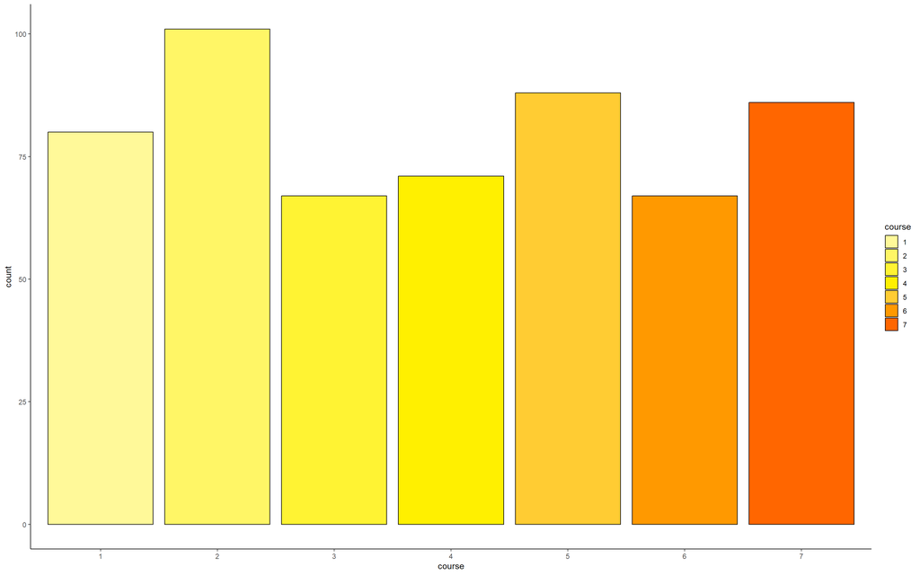

```r
  ggplot(hogwarts)+
  geom_bar(aes(x = course, fill = course),
           colour = 'black')+
  scale_fill_manual(values = c('1'= "#FFF999",
                               '2'= "#FFF666",
                               '3'= "#FFF333",
                               '4'= "#FFF000",
                               '5'= "#FFCC33",
                               '6'= "#FF9900",
                               '7'= "#FF6600"))+

  theme_classic()
```

### Задание 2

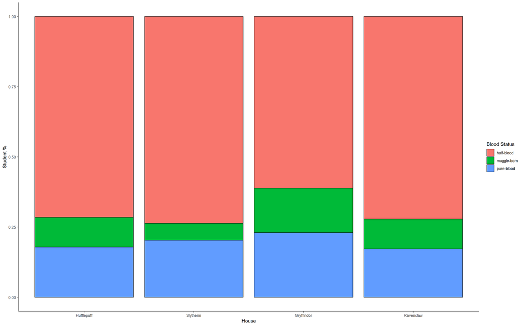

```r
hogwarts %>%
  ggplot()+
  geom_bar(aes(x = fct_infreq(house), fill = bloodStatus),
          colour = 'black',
          position = 'fill')+
  scale_x_discrete(name = "House")+
  scale_fill_discrete(name = "Blood Status")+
  scale_y_continuous(name = "Student %")+
  theme_classic()
```

Из полученного графика распределению студентов по факультетам и их статусу крови можно сделать вывод, что в процентном отношении самое большое количество магглорожденных студентов наблюдается на факультете Гриффиндор, что в целом очень даже объясняется их факультетскими ценностями.

Если же посмотреть на процентное отношение количества чистокровных магов в каждом из факультетов, то суждение, что в Слизерине находятся только чистокровные маги, оказывается неверным. Можно заметить, что в Пуффендуе количество студентов больше, чем в Слизерине, однако чистокровных магов практически столько же в процентном отношении. Таким образом, Слизерин нельзя считать единственным факультетом для чистокровных волшебников.

### Задание 3

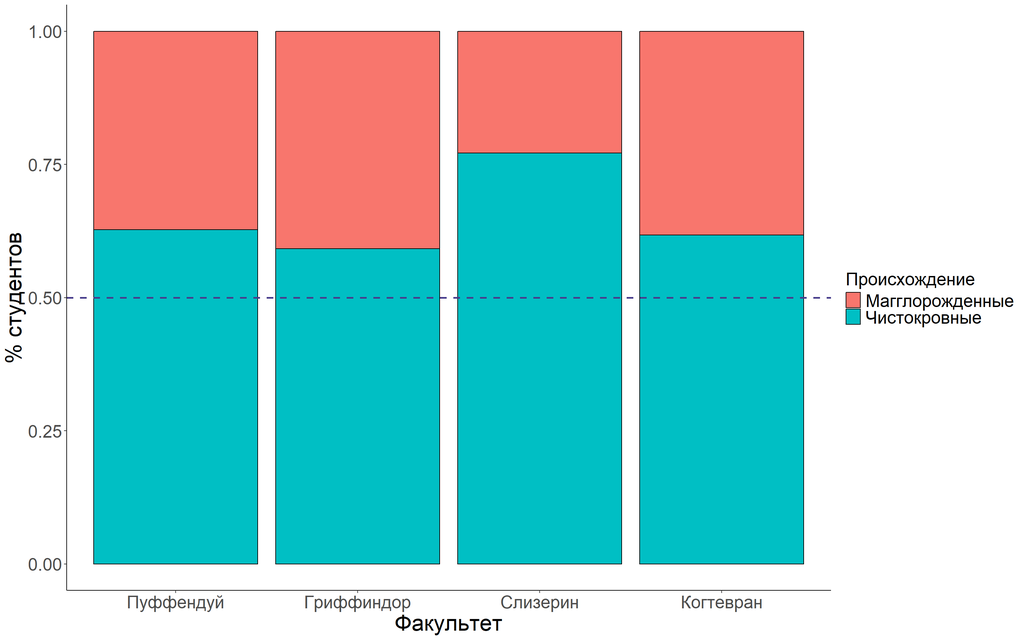

```r
theme_custom <- theme(
    axis.text = element_text(size = 20),
    axis.title = element_text(size = 25),
    legend.title = element_text(size = 20),
    legend.text = element_text(size = 20)
  )

hogwarts_new <- hogwarts[hogwarts$bloodStatus == 'pure-blood' | hogwarts$bloodStatus == 'muggle-born', ]

hogwarts_new %>%
  ggplot()+
  geom_bar(aes(x = fct_infreq(house), fill = bloodStatus),
          colour = 'black',
          position = 'fill')+
  geom_hline(yintercept = 0.5,
             linewidth = 1,
             linetype = "dashed",
             colour = "slateblue4")+
  scale_x_discrete(name = "Факультет",
                   breaks = c('Hufflepuff', 'Gryffindor', 'Slytherin', 'Ravenclaw'),
                   labels = c('Пуффендуй', 'Гриффиндор', 'Слизерин', 'Когтевран'))+
  scale_fill_discrete(name = "Происхождение",
                      breaks = c('muggle-born', 'pure-blood'),
                      labels = c('Магглорожденные', 'Чистокровные'))+
  scale_y_continuous(name = "% студентов")+
  theme_classic()+
  theme_custom
```

## Боксплоты

### Задание 1

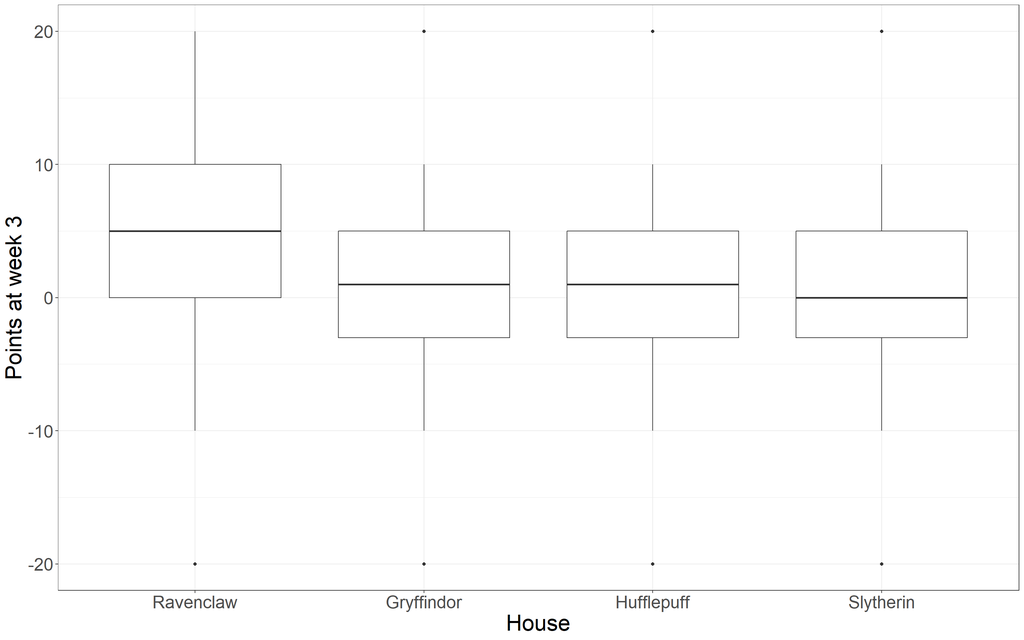

```r
hogwarts %>%
  ggplot()+
    geom_boxplot(aes(x = reorder(house, week_3, decreasing = TRUE) , y = week_3))+
  scale_x_discrete(name = 'House')+
  scale_y_continuous(name = 'Points at week 3')+
  theme_bw()+
  theme_custom
```

### Задание 2

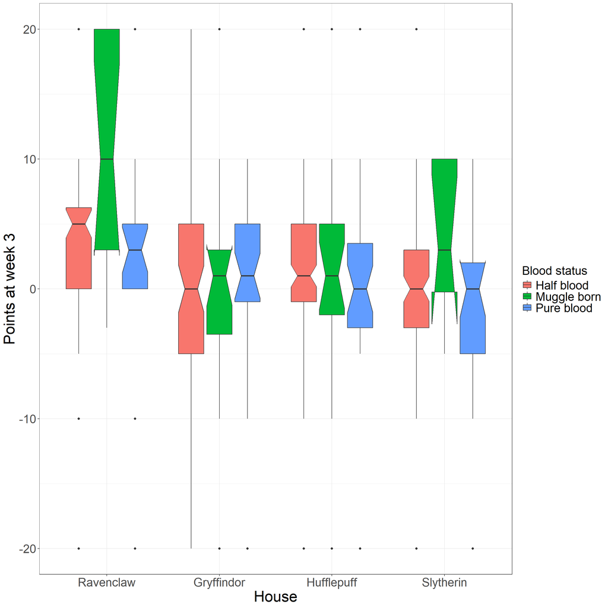

```r
hogwarts %>%
  ggplot(aes(x = reorder(house, week_3, decreasing = TRUE) , y = week_3, fill = bloodStatus))+
    geom_boxplot(notch = TRUE)+
  scale_x_discrete(name = 'House')+
  scale_y_continuous(name = 'Points at week 3')+
  scale_fill_discrete(name = 'Blood status',
                      breaks = c('half-blood', 'muggle-born' , 'pure-blood'),
                      labels = c('Half blood', 'Muggle born', 'Pure blood'))+
  theme_bw()+
  theme_custom
```

### Задание 3

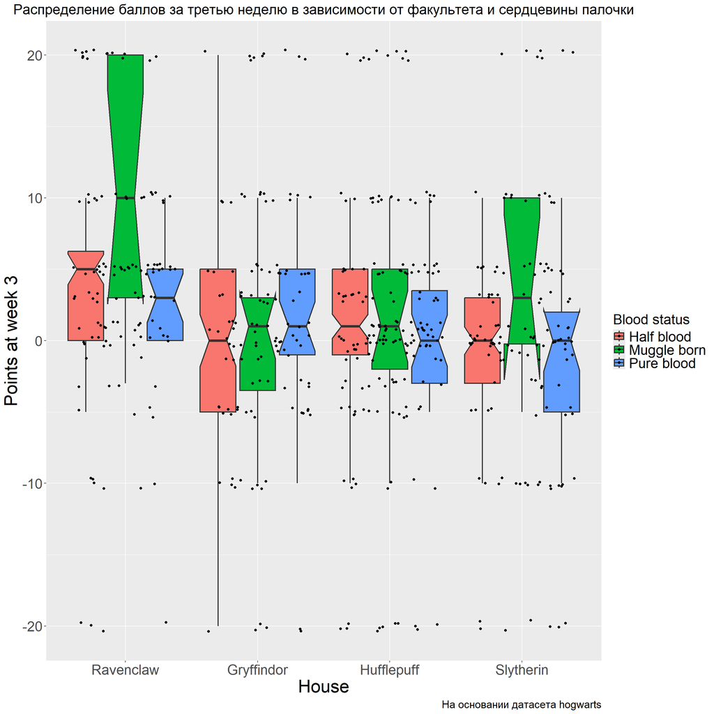

```r
##Данный график выполнен без использования кастомной темы и bw, чтобы затем применить тему в задании №3 из "Разное"
boxplot3 <-
  hogwarts %>%
  ggplot(aes(x = reorder(house, week_3, decreasing = TRUE) , y = week_3, fill = bloodStatus))+
  geom_boxplot(notch = TRUE, outliers = FALSE, linewidth = 0.8, width = 0.9)+
  geom_jitter()+
  scale_x_discrete(name = 'House')+
  scale_y_continuous(name = 'Points at week 3')+
  scale_fill_discrete(name = 'Blood status',
                      breaks = c('half-blood', 'muggle-born' , 'pure-blood'),
                      labels = c('Half blood', 'Muggle born', 'Pure blood'))+
   labs(title = "Распределение баллов за третью неделю в зависимости от факультета и сердцевины палочки",
       caption = "На основании датасета hogwarts")+
  theme(
    plot.title = element_text(size = 20, hjust = 0.5),
    plot.caption = element_text(size = 15)
  )+
  theme_custom

boxplot3
```

## Разное

### Задание 1

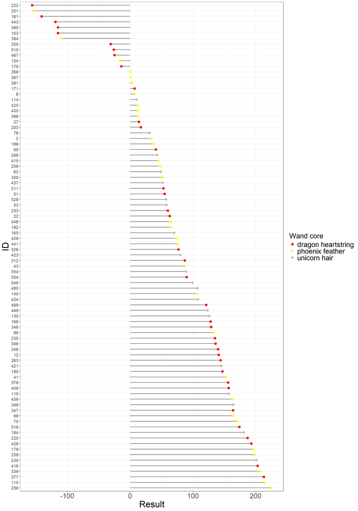

```r
hogwarts %>%
  filter(course == 5) %>%
  ggplot()+
  geom_segment(aes(x = 0,
                   xend = result,
                   y = reorder(id, result, decreasing = TRUE),
                   yend = reorder(id, result, decreasing = TRUE)))+
  geom_point(aes(x =  result,
                 y = reorder(id, result, decreasing = TRUE),
                 colour = wandCore),
             size = 3)+
  scale_colour_manual(name = 'Wand core',
                      values = c("dragon heartstring"= "red",
                               "phoenix feather"= "yellow",
                               "unicorn hair"= "grey"))+
  labs(x = 'Result',
       y = 'ID')+
  theme_bw()+
  theme_custom+
  theme(axis.text.y = element_text(size = 12))
```

### Задание 2

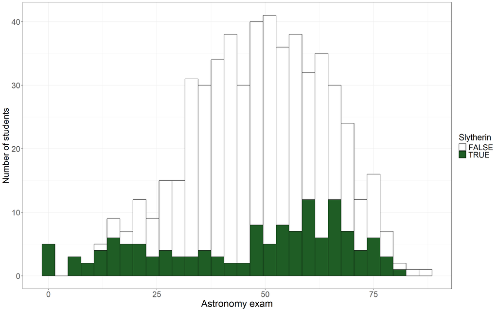

```r
hogwarts %>%
  ggplot(aes(`Astronomy exam`, fill = house == 'Slytherin'))+
  geom_histogram(color = 'black')+
  theme_bw()+
  scale_fill_manual(name = 'Slytherin',
                    values = c('TRUE' = "#1F5D25",
                               'FALSE'= "white"))+
  labs(y = 'Number of students')+
  theme(
    axis.text.x = element_text(size = 18),
    axis.text.y = element_text(size = 18),
    legend.text = element_text(size = 18),
    axis.title.y = element_text(size = 20),
    legend.title = element_text(size = 20),
    axis.title.x = element_text(size = 22)
    )
```

### Задание 3

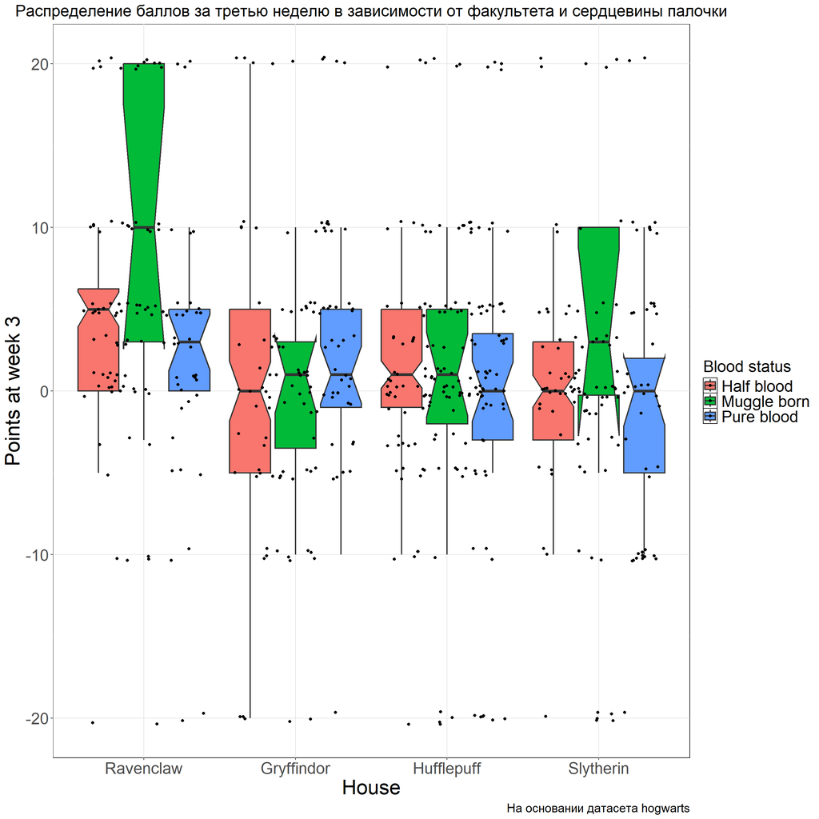

```r
theme_custom_new <- theme(
    axis.text = element_text(size = 20),
    axis.title = element_text(size = 25),
    legend.title = element_text(size = 20),
    legend.text = element_text(size = 20),
    panel.background = element_rect(fill = 'white', color = 'black'),
    panel.grid.major = element_line(colour = "gray90")
)

boxplot3 + theme_custom_new
```

## Фасетирование

### Задание 1

По моему мнению, для визуализации гистрограмм лучше использовать фасетирование по столбцам, так как это позволит наглядно сравнить значения разных групп данных. Например, в примере из задания фасетирование по столбцам факультетов позволяет увидеть, что баллы слизеринцев в большей мере сконцентрированы у высоких значений оценок, в отличие от других факультетов.

Для визуализации violin-plot можно использовать оба способа фасетирования. Выбор зависит от конкретной задачи и структуры данных. Если нужно сравнить несколько распределений, то лучше использовать фасетирование по строкам. Если необходимо сравнить одно распределение в разных условиях, то можно выбрать фасетирование по столбцам.

Общее правило сформулировать сложно, так как многое зависит от задачи визуализации. Всегда можно попробовать разные способы и посмотреть, какой из них лучше подойдет. У нас же не одна попытка)

### Задание 2

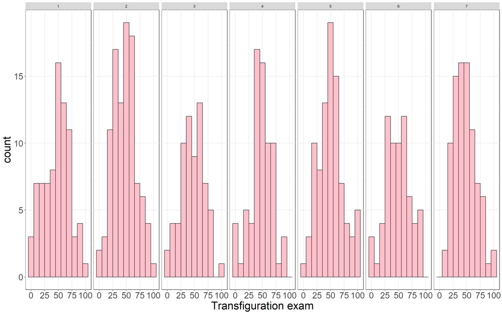

```r
hogwarts %>%
  ggplot()+
  geom_histogram(aes(x = `Transfiguration exam`), fill = 'pink', color = 'black', bins = ceiling(log2(nrow(hogwarts))+1))+
  theme_custom_new+
  facet_grid(.~course)
```

### Задание 3

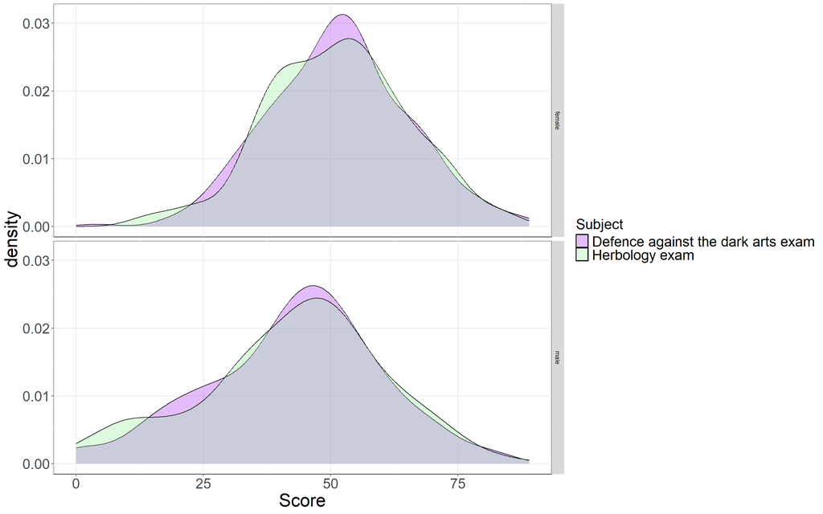

```r
hogwarts %>%
  select(id, sex, `Defence against the dark arts exam`, `Herbology exam`) %>%
  pivot_longer(!c(id, sex),
               names_to ='Subject',
               values_to = 'Score') %>%
  ggplot()+
  geom_density(aes(x = Score, fill = Subject), alpha = 0.3)+
  scale_fill_manual(values = c("Defence against the dark arts exam" = "purple", "Herbology exam" = "lightgreen"),
    name = "Subject",
    labels = c("Defence against the dark arts exam", "Herbology exam"))+
  facet_grid(sex~.)+
  theme_custom_new
```